# Math 120 Lec 08

Ali Miller

16 September, 2019

## Outliers

- Note: robust statistics are not susceptible to outliers!
- Lin reg stuff (i.e. r and b0 and b1) are not very robust – outliers can change our model!
- Always need to investigate, there are some common patterns. (See board examples, text example)
- In the text, “influential points” are points that **do** affect the linear model. We can usually spot them: they’re far away from the other (horizontally), and don’t fit the linear pattern.
- Summary from board examples:
  - Sometimes, outliers can make a weak relationship seem strong (eg #3).
  - Sometimes, outliers can make a strong relationship seem weak. (eg #2).
  - Sometimes, outliers don’t really change anything (#1).
- Note: “high leverage points” are far away on x-axis (left/right). Note, it doesn’t **have to** high leverage to change the model.
- So, generally, we run the numbers twice! It’s easy to filter out the outliers, and check for sure whether or not the model was affectd. R makes this easy!

## Case Studies

### iris data

```r
iris %>% head
```

|  | Sepal.Length | Sepal.Width | Petal.Length | Petal.Width | Species |
| --- | --- | --- | --- | --- | --- |
| 1 | 5.1 | 3.5 | 1.4 | 0.2 | setosa |
| 2 | 4.9 | 3.0 | 1.4 | 0.2 | setosa |
| 3 | 4.7 | 3.2 | 1.3 | 0.2 | setosa |
| 4 | 4.6 | 3.1 | 1.5 | 0.2 | setosa |
| 5 | 5.0 | 3.6 | 1.4 | 0.2 | setosa |
| 6 | 5.4 | 3.9 | 1.7 | 0.4 | setosa |

Question: is there a lin rel btween sepal length and sepal width? Let’s look!

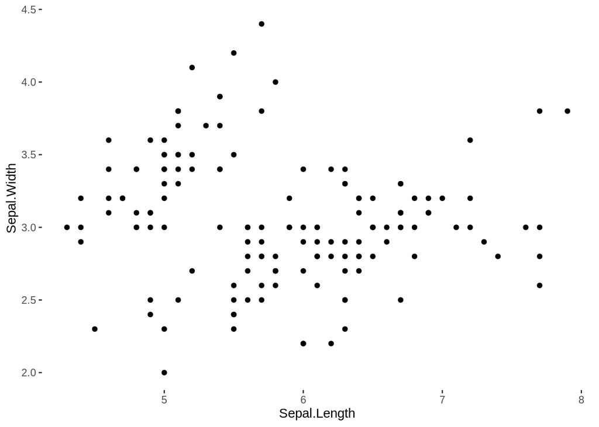

```r
#First, always look at scatterplot!


qplot(Sepal.Length, Sepal.Width, data=iris)
```

First observation: doesn’t seem like there’s a strong lin rel. But, let’s look at the numbers.

First, r:

```r
#expect it to be small, close to zero

cor(iris$Sepal.Length, iris$Sepal.Width)
```

```
## [1] -0.1175698
```

So, we were right: the correl is very weak. What’s going on with the model?

```r
#use lm

irisModel <- lm(Sepal.Width ~ Sepal.Length, data=iris)

summary(irisModel)
```

```
##
## Call:
## lm(formula = Sepal.Width ~ Sepal.Length, data = iris)
##
## Residuals:
##     Min      1Q  Median      3Q     Max
## -1.1095 -0.2454 -0.0167  0.2763  1.3338
##
## Coefficients:
##              Estimate Std. Error t value Pr(>|t|)
## (Intercept)   3.41895    0.25356   13.48   <2e-16 ***
## Sepal.Length -0.06188    0.04297   -1.44    0.152
## ---
## Signif. codes:  0 '***' 0.001 '**' 0.01 '*' 0.05 '.' 0.1 ' ' 1
##
## Residual standard error: 0.4343 on 148 degrees of freedom
## Multiple R-squared:  0.01382,    Adjusted R-squared:  0.007159
## F-statistic: 2.074 on 1 and 148 DF,  p-value: 0.1519
```

Equation:

$$\hat{y} =3.4189-0.0619x$$

Note about rounding: I don’t really care. Give me 3 decimals.

**Residuals**

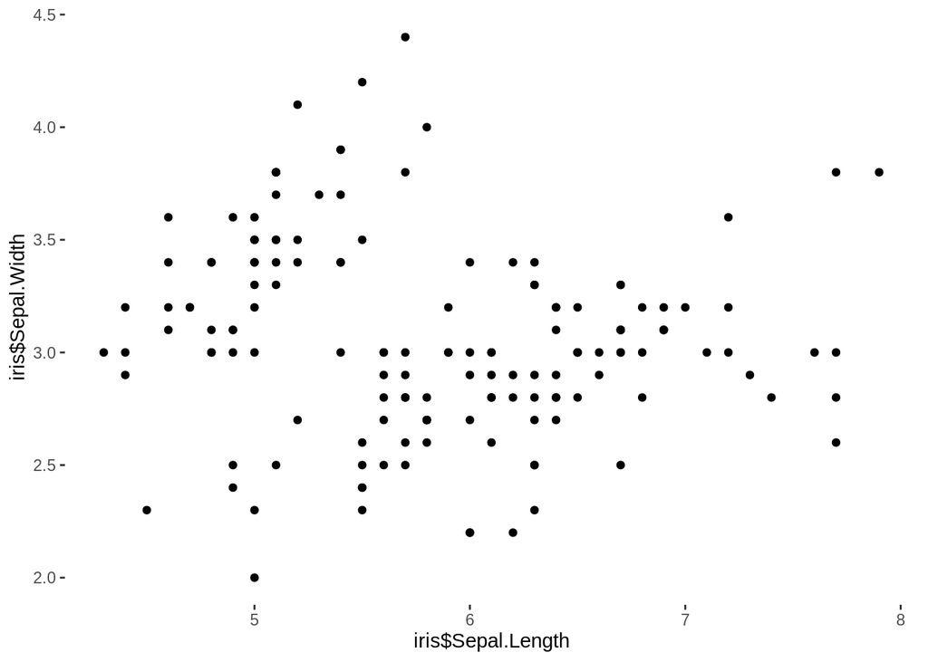

```r
# for resid plot, x is original x data, y is resids in lm data

qplot(iris$Sepal.Length, iris$Sepal.Width)
```

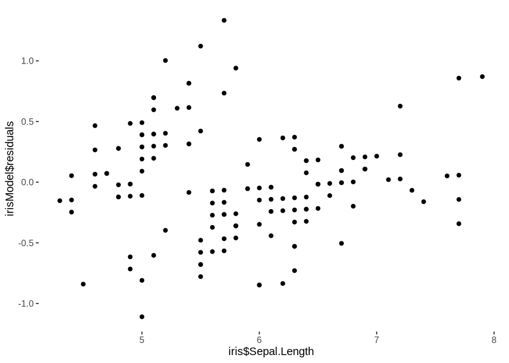

```r
qplot(iris$Sepal.Length, irisModel$residuals)
```

Important question: do we see a pattern?

Note, what kind of “pattern”? Two main kinds:

- curve. like a parabola.
- homskedasticity

Remember, if there is a pattern, it suggests we can do better than the lm. If no pattern, then lm is as good as it gets.

Here: no obvious curve, yes homoskedastic, I think there’s no pattern. I.e., we **can’t** do better than lm.

Interesting note: even though the correlation is very weak, we see from residual analysis that we can’t do better than the lm.

**Coefficient of Determination $R^2$**

Remember: $R^2$ is the percent of variation in y data that’s because of the linear rel with x.

```r
summary(irisModel)
```

```
##
## Call:
## lm(formula = Sepal.Width ~ Sepal.Length, data = iris)
##
## Residuals:
##     Min      1Q  Median      3Q     Max
## -1.1095 -0.2454 -0.0167  0.2763  1.3338
##
## Coefficients:
##              Estimate Std. Error t value Pr(>|t|)
## (Intercept)   3.41895    0.25356   13.48   <2e-16 ***
## Sepal.Length -0.06188    0.04297   -1.44    0.152
## ---
## Signif. codes:  0 '***' 0.001 '**' 0.01 '*' 0.05 '.' 0.1 ' ' 1
##
## Residual standard error: 0.4343 on 148 degrees of freedom
## Multiple R-squared:  0.01382,    Adjusted R-squared:  0.007159
## F-statistic: 2.074 on 1 and 148 DF,  p-value: 0.1519
```

$R^2$ = .0138, i.e., about 1.38% of all the variation in Sepal Width is due to the rel between sepal width and sepal length.

I.e., almomst nothing!!! Not surprising, considering everything else we’ve seen in the analysis. This is a terrible model!